# **Tree**

Pohon adalah struktur data hierarkis yang terdiri dari simpul-simpul yang dihubungkan oleh sisi-sisi.

Setiap node berisi sebuah nilai dan referensi ke node anaknya.

## **Pohon**

Struktur data Tree mirip dengan Linked List karena setiap node berisi data dan dapat dihubungkan ke node lain.

Sebelumnya kita telah membahas struktur data seperti Array, Linked List, Stack, dan Queue. Semua ini adalah struktur linier, yang berarti setiap elemen mengikuti elemen lain secara berurutan. Namun, Tree berbeda. Dalam sebuah Tree, satu elemen dapat memiliki banyak elemen 'berikutnya', memungkinkan struktur data untuk bercabang ke berbagai arah.

Struktur data ini disebut "pohon" karena bentuknya menyerupai struktur pohon.

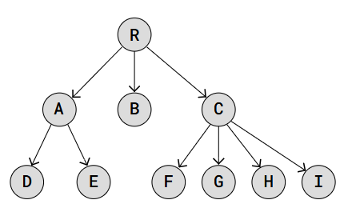

Struktur data Tree dapat berguna dalam banyak kasus:

- Data Hierarkis: Sistem file, model organisasi, dll.
- Basis data: Digunakan untuk pengambilan data dengan cepat.
- Tabel Perutean: Digunakan untuk merute data dalam algoritma jaringan.
- Pengurutan/Pencarian: Digunakan untuk mengurutkan data dan mencari data.
- Antrian Prioritas: Struktur data antrian prioritas umumnya diimplementasikan menggunakan pohon, seperti heap biner.

## **Jenis-jenis Pohon**

Pohon adalah struktur data fundamental dalam ilmu komputer, yang digunakan untuk merepresentasikan hubungan hierarkis. Tutorial ini membahas beberapa jenis pohon utama.

**Pohon Biner:** Setiap simpul memiliki hingga dua anak, yaitu simpul anak kiri dan simpul anak kanan. Struktur ini merupakan dasar untuk jenis pohon yang lebih kompleks seperti Pohon Pencarian Biner dan Pohon AVL.

**Pohon Pencarian Biner (BST):** Suatu jenis Pohon Biner di mana untuk setiap simpul, simpul anak kiri memiliki nilai yang lebih rendah, dan simpul anak kanan memiliki nilai yang lebih tinggi.

**Pohon AVL:** Jenis Pohon Pencarian Biner yang menyeimbangkan diri sendiri sehingga untuk setiap simpul, perbedaan tinggi antara subpohon kiri dan kanan paling banyak satu. Keseimbangan ini dipertahankan melalui rotasi ketika simpul disisipkan atau dihapus.

Masing-masing struktur data ini dijelaskan secara detail pada halaman-halaman berikutnya, termasuk animasi dan cara mengimplementasikannya.

## **Pohon vs. Array dan Daftar Berantai**

Keunggulan Struktur Pohon dibandingkan Array dan Linked List:

- **Array** cepat ketika Anda ingin mengakses elemen secara langsung, seperti elemen nomor 700 dalam array yang berisi 1000 elemen misalnya. Tetapi memasukkan dan menghapus elemen memerlukan pergeseran elemen lain di memori untuk memberi tempat bagi elemen baru, atau untuk menggantikan elemen yang dihapus, dan itu memakan waktu.
- **Linked list** cepat dalam menyisipkan atau menghapus node, tidak memerlukan pergeseran memori, tetapi untuk mengakses elemen di dalam list, list harus ditelusuri, dan itu membutuhkan waktu.
- **Pohon** , seperti Pohon Biner, Pohon Pencarian Biner, dan Pohon AVL, sangat bagus dibandingkan dengan Array dan Daftar Bertautan karena pohon CEPAT dalam mengakses sebuah node, DAN cepat dalam menghapus atau menyisipkan sebuah node, tanpa perlu pergeseran memori.

## **Tree**

merupakan struktur data yang berbentuk non linear, berbeda dengan struktur data stack, queue, ataupun deque. Bentuk Tree di computer science hampir sama dengan tree yang terdapat pada ekosistem biologi, yaitu keduanya memiliki root, leaves, dan branches. Hanya saja, jika pada ekosistem biologi, akar terletak di bagian paling bawah dan daun ataupun batang terletak diatasnya, maka tree pada computer science agak sedikit berbeda, yaitu, akar terletak pada bagian paling atas, sedangkan daun dan cabangnya berada di bawahnya.

Pada computer science, pencarian solusi dimulai dari root, bergerak ke bawah mengikuti cabangnya atau edge, sampai dengan leaves atau daun. Informasi yang terdapat pada daun inilah yang merupakan solusi yang dicari. Contoh tree dapat dapat dilihat pada Gambar 1 berikut:

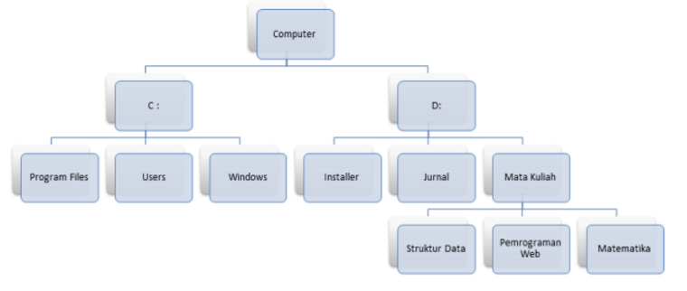

**Gambar 1. Bentuk Tree**

Suatu tree juga dapat dilihat sebagai suatu struktur data yang memiliki dua buah komponen, yaitu root dan subtree, dimana sebuah tree dapat terdiri dari sebuah root dan nol atau lebih dari satu subtree.

Subtree sendiri juga merupakan sebuah tree. Root dari subtree dihubungkan dengan edge ke root dari tree. Hal ini dapat dipandang sebagai definisi rekursif. Definisi ini dapat dilihat pada Gambar 2, sebagai berikut :

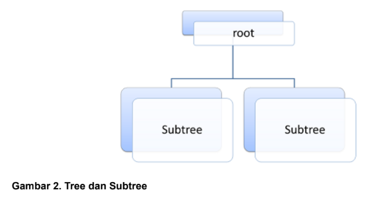